# Chapter 10: Prediction

Runnable workbook for Regression with R and Python

This runnable workbook supplements the reference workbook. It adds setup code and lightweight fixes so the chapter can usually be rendered and run end-to-end.

- Runnable companion script: R/chapter10.R
- Reference workbook: chapter10_workbook.Rmd
- Textbook chapter: `Prediction`
- Package installation lines are shown as comments and are not run automatically during rendering.

## Example with training and test data

### Box 01

Textbook context: Section: Training data, test data and cross-validation.

```r
    set.seed(12)
    n <- nrow(df)
    train_share <- .8
    train_ind <- sample(1:n, train_share * n, replace=FALSE)
    test_ind <- setdiff(1:n, train_ind)
    df_train <- df[train_ind, ]
    df_test <- df[test_ind, ]
```

## Ridge and lasso in R

### Box 02

Textbook context: Section: Predictions with many independent variables | Subsection: Scale dependence with ridge and lasso regression.

```r
# install.packages("glmnet")  # install manually if needed
 library(glmnet)
```

### Box 03

Textbook context: Section: Predictions with many independent variables | Subsection: Scale dependence with ridge and lasso regression.

```r
  df <- read.csv("apartment_price_data.csv")
  df <- df[complete.cases(df), ]
```

### Box 04

Textbook context: Section: Predictions with many independent variables | Subsection: Scale dependence with ridge and lasso regression.

```r
 dfX <- df[, names(df) != "price"]
```

### Box 05

Textbook context: Section: Predictions with many independent variables | Subsection: Scale dependence with ridge and lasso regression.

```r
 X <- makeX(dfX)
 Y <- df$price
 ridge_model <- glmnet(X, Y, alpha = 0, lambda = 0.1)
 ridge_model_cv <- cv.glmnet(X, Y, alpha = 0)
```

### Box 06

Textbook context: Section: Predictions with many independent variables | Subsection: Scale dependence with ridge and lasso regression.

```r
 yhat <- predict(ridge_model, newx = X)
```

### Box 07

Textbook context: Section: Predictions with many independent variables | Subsection: Scale dependence with ridge and lasso regression.

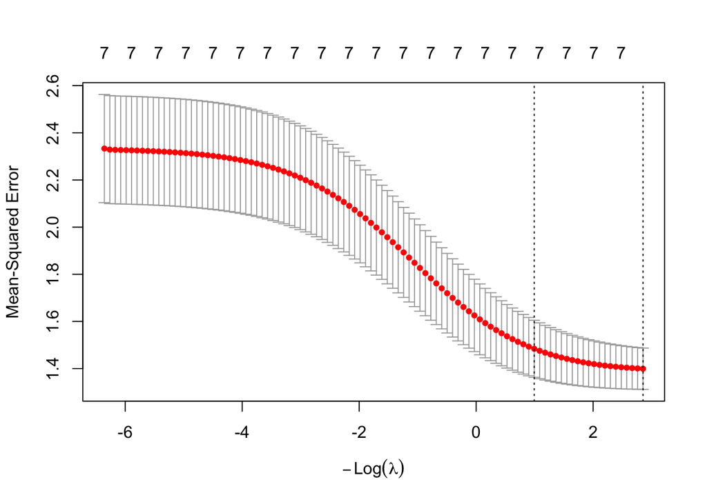

```r
 plot(ridge_model_cv)
```

## Regression tree in R

### Box 08

Textbook context: Section: Tree-based regression models.

```r
# install.packages("rpart")  # install manually if needed
# install.packages("rpart.plot")  # install manually if needed
  library(rpart)
  library(rpart.plot)
```

### Box 09

Textbook context: Section: Tree-based regression models.

```r
 df <- read.csv("apartment_price_data.csv")
```

### Box 10

Textbook context: Section: Tree-based regression models.

```r
 tree_model <- rpart(price ~ living_area + monthly_fee,
 data=df, control=rpart.control(
 minsplit = 20, minbucket = 5, cp=0))
```

### Box 11

Textbook context: Section: Tree-based regression models.

[figure not shown]

```r
  rpart.plot(tree_model)
```

### Box 12

Textbook context: Section: Tree-based regression models.

```r
 pruned_tree <- prune(tree_model, cp=.03)
```

### Box 13

Textbook context: Section: Tree-based regression models.

```r
 printcp(tree_model)
```

```
#>
#> Regression tree:
#> rpart(formula = price ~ living_area + monthly_fee, data = df,
#>     control = rpart.control(minsplit = 20, minbucket = 5, cp = 0))
#>
#> Variables actually used in tree construction:
#> [1] living_area monthly_fee
#>
#> Root node error: 2186.9/1000 = 2.1869
#>
#> n= 1000
#>
#>            CP nsplit rel error  xerror     xstd
#> 1  7.8288e-02      0   1.00000 1.00218 0.105658
#> 2  3.0299e-02      1   0.92171 0.98698 0.091438
```

[output cut: 53 more lines]

## Comparison of the different prediction models

### Box 14

Textbook context: Section: Example: housing prices.

```r
 df <- read.csv("apartment_price_data.csv")
 df$elevator_missing <- as.integer(is.na(df$elevator))
 df$elevator[is.na(df$elevator)] <- 0
 df$living_area2 <- df$living_area^2
 df$monthly_fee2 <- df$monthly_fee^2
 df <- df[complete.cases(df), ]
 for (room_size in 2:6) {
   room_var <- paste0("room_size_", room_size)
   df[[room_var]] <- as.integer(df$number_of_rooms == room_size)
   df[[paste0("city_area_", room_var)]] <- df$city_area * df[[room_var]]
 }
 year_list10 <- seq(from=1900, to=2010, by=10)
 for (year in year_list10) {
   decade_var <- paste0("build_decade_", year)
   df[[decade_var]] <- as.integer(df$build_year >= year & df$build_year <= year + 9)
   df[[paste0("city_area_", decade_var)]] <- df$city_area * df[[decade_var]]
 }
 year_list1 <- sort(unique(df$build_year))
 ref_year <- year_list1[1]
 for (year in year_list1) {
   if (year == ref_year) next
   year_var <- paste0("build_year_", year)
   df[[year_var]] <- as.integer(df$build_year == year)
   df[[paste0("city_area_", year_var)]] <- df$city_area * df[[year_var]]
 }
 year_list10 <- seq(from=1900, to=2010, by=10)
```

### Box 15

Textbook context: Section: Example: housing prices.

```r
  room_vars <- ls(df, pat="^room_size_|^city_area_room_size_")
```

### Box 16

Textbook context: Section: Example: housing prices.

```r
 build_decade_vars <- ls(df,
 pat="^build_decade_|^city_area_build_decade_")
 build_year_vars <- ls(df,
 pat="^build_year_|^city_area_build_year_")
```

### Box 17

Textbook context: Section: Example: housing prices.

```r
  rest_vars <- c("living_area", "new_production",
                 "monthly_fee", "city_area", "elevator",
                 "elevator_missing", "living_area2",
                 "monthly_fee2")
  tree_vars <- c("living_area", "new_production",
                 "monthly_fee", "city_area", "elevator",
                 "number_of_rooms", "build_year")
```

### Box 18

Textbook context: Section: Example: housing prices.

```r
 varlist_model1 <- c(room_vars, build_year_vars, rest_vars)
 varlist_model10 <- c(room_vars, build_decade_vars, rest_vars)
 X1 <- makeX(df[, varlist_model1])
 X10 <- makeX(df[, varlist_model10])
 Y <- df$price
```

### Box 19

Textbook context: Section: Example: housing prices.

```r
 formOLS1 <- paste(varlist_model1, collapse="+")
 formOLS1 <- paste("price ~ ", formOLS1)
```

### Box 20

Textbook context: Section: Example: housing prices.

```r
  formOLS10 <- paste("price ~ ",
    paste(varlist_model10, collapse="+"))
  formCART <- paste("price ~ ",
    paste(tree_vars, collapse="+"))
```

### Box 21

Textbook context: Section: Example: housing prices.

```r
 set.seed(12)
 n <- nrow(df)
 ind_train <- sample(1:n, 4/5 * n, replace=FALSE)
 ind_test <- setdiff(1:n, ind_train)
```

### Box 22

Textbook context: Section: Example: housing prices.

```r
  ols_model1 <- lm(formOLS1, data=df[ind_train, ])
  ridge_model1 <- cv.glmnet(
    X1[ind_train, ], Y[ind_train], alpha=0)
  lasso_model1 <- cv.glmnet(
    X1[ind_train, ], Y[ind_train], alpha=1)

  ols_model10 <- lm(formOLS10, data=df[ind_train, ])
  ridge_model10 <- cv.glmnet(
    X10[ind_train, ], Y[ind_train], alpha=0)
  lasso_model10 <- cv.glmnet(
    X10[ind_train, ], Y[ind_train], alpha=1)

    CART_model = rpart(formCART, data=df[ind_train, ],
                     control=rpart.control(
                      minsplit = 20, minbucket = 5, cp=0))
  c <- printcp(CART_model)
```

```
#>
#> Regression tree:
#> rpart(formula = formCART, data = df[ind_train, ], control = rpart.control(minsplit = 20,
#>     minbucket = 5, cp = 0))
#>
#> Variables actually used in tree construction:
#> [1] build_year      city_area       elevator        living_area
#> [5] monthly_fee     number_of_rooms
#>
#> Root node error: 1749.9/739 = 2.3679
#>
#> n= 739
#>
#>            CP nsplit rel error  xerror     xstd
#> 1  0.22464368      0   1.00000 1.00325 0.126412
```

[output cut: 51 more lines]

```r
  s <- c[, "xerror"]
  alpha <- c[, "CP"][s == min(s)]
  pruned_tree <- prune(CART_model, cp=alpha)
```

### Box 23

Textbook context: Section: Example: housing prices.

```r
  yhat_ols1 <- predict(ols_model1, newdata=df)
  yhat_ols10 <- predict(ols_model10, newdata=df)
  yhat_ridge1 <- predict(ridge_model1, newx=X1,
                         s="lambda.min")
  yhat_ridge10 <- predict(ridge_model10, newx=X10,
                          s="lambda.min")
  yhat_lasso1 <- predict(lasso_model1, newx=X1,
                         s="lambda.min")
  yhat_lasso10 <- predict(lasso_model10, newx=X10,
                          s="lambda.min")
  yhat_tree <- predict(pruned_tree, newdata = df)
```

### Box 24

Textbook context: Section: Example: housing prices.

```r
 YHAT_models <- list(yhat_ols1, yhat_ridge1, yhat_lasso1,
 yhat_ols10, yhat_ridge10, yhat_lasso10,
 yhat_tree)
 MSE_train <- c()
 MSE_test <- c()
 for (yhat in YHAT_models) {
 mse_train <- mean((Y[ind_train] - yhat[ind_train])^2)
 mse_test <- mean((Y[ind_test] - yhat[ind_test])^2)
 MSE_train <- c(MSE_train, mse_train)
 MSE_test <- c(MSE_test, mse_test)
 }
```